# Kaggle_Exploring_the_Titanic_data_using_R

LF

19/01/2018

# Introduction

Here I explore the Titanic dataset using the caret package in R. There are four parts to the analysis: (1) Missing value imputation, (2) Feature engineering, (3) Basic data exploration, (4) Model building

## Load and check data

```r
rm(list = ls())
library(ggplot2) # visualization
library(ggthemes) # visualization
library(scales) # visualization
library(dplyr) # data manipulation
library(caret) # classification package
library(fBasics) # for basic measures of data distributions
```

```r
set.seed(32343)
titanic <- read.csv('/Users/lewisforder/Documents/repos/Kaggle_Titanic_data/train.csv', stringsAsFactors = F)
test  <- read.csv('/Users/lewisforder/Documents/repos/Kaggle_Titanic_data/test.csv', stringsAsFactors = F)

titanic$data_type <- 'training' # label the data in case we remove cases later on
test$data_type <- 'test'
```

# Missing values imputation

Now let’s check the data and look for missing values in the training set and in the test set.

```r
# Double check data types
sapply(titanic, class)
```

```
## PassengerId    Survived      Pclass        Name         Sex         Age
##   "integer"   "integer"   "integer" "character" "character"   "numeric"
##       SibSp       Parch      Ticket        Fare       Cabin    Embarked
##   "integer"   "integer" "character"   "numeric" "character" "character"
##   data_type
## "character"
```

```r
# Double check presence of missing values in our predictors of interest
sapply(titanic, function(x) sum(is.na(x)))
```

```
## PassengerId    Survived      Pclass        Name         Sex         Age
##           0           0           0           0           0         177
##       SibSp       Parch      Ticket        Fare       Cabin    Embarked
##           0           0           0           0           0           0
##   data_type
##           0
```

```r
sapply(test, function(x) sum(is.na(x)))
```

```
## PassengerId      Pclass        Name         Sex         Age       SibSp
##           0           0           0           0          86           0
##       Parch      Ticket        Fare       Cabin    Embarked   data_type
##           0           0           1           0           0           0
```

```r
median(titanic$Fare)
```

```
## [1] 14.4542
```

```r
median(test$Fare, na.rm=TRUE)
```

```
## [1] 14.4542
```

```r
which(is.na(test$Fare), arr.ind=TRUE) # get row number
```

```
## [1] 153
```

```r
test$Fare[153] <- median(test$Fare, na.rm=TRUE) # impute with median value
```

In fact these median values are identical, a good sign that our test data is (hopefully) an accurate representation of the training data. There’s also a couple of empty (not NA) values for the embared feature in the training set. We’ll remove those rows - there are only two of them so this shouldn’t decrease the model accuracy.

```r
# Get row indices of missing data and then remove them
titanic[which(titanic$Embarked == ''), ]
```

```
##     PassengerId Survived Pclass                                      Name
## 62           62        1      1                       Icard, Miss. Amelie
## 830         830        1      1 Stone, Mrs. George Nelson (Martha Evelyn)
##        Sex Age SibSp Parch Ticket Fare Cabin Embarked data_type
## 62  female  38     0     0 113572   80   B28           training
## 830 female  62     0     0 113572   80   B28           training
```

```r
titanic <- titanic[-c(62, 830), ]

titanic[which(titanic$Embarked == ''), ] # double check the correct rows were removed (there should be no rows returned here)
```

```
##  [1] PassengerId Survived    Pclass      Name        Sex
##  [6] Age         SibSp       Parch       Ticket      Fare
## [11] Cabin       Embarked    data_type
## <0 rows> (or 0-length row.names)
```

## Impute missing age data using k-nearest neighbours

OK, so we’ve got 177 missing age values in the training dataset and 86 in the testing set. That’s too many to remove so let’s try and impute these missing data using k-nearest neighbours imputation.

Firstly, let’s check how well this procedure works on data for which we do know the correct answer. We can do this by randomly assigning NA to some real age values, carrying out the imputation on these ‘known’ data, and then comparing this to the real data.

```r
titanic$age_Zscore <- (titanic$Age-mean(titanic$Age, na.rm=TRUE))/sd(titanic$Age, na.rm=TRUE) # make a column of age data as z-scores (the k-nearest neighbours will be z-scores)

Subs1<-subset(titanic, (!is.na(titanic[,6]))) # omit data with NA age values

# And now check for missing age values (there should be none)
sapply(Subs1, function(x) sum(is.na(x)))
```

```
## PassengerId    Survived      Pclass        Name         Sex         Age
##           0           0           0           0           0           0
##       SibSp       Parch      Ticket        Fare       Cabin    Embarked
##           0           0           0           0           0           0
##   data_type  age_Zscore
##           0           0
```

```r
# now randomly make some values NA
Subs1$Age_Z_NAs <- Subs1$age_Zscore # the capAve variable will be assigned NAs
selectNA <- rbinom(dim(Subs1)[1],size = 1,prob = 0.2)==1 #use random binomialy function to get index of numbers to be missing. Let's make the same proportion NAs as actual NAs (~ 20% missing)
Subs1$Age_Z_NAs[selectNA] <- NA #assign NAs to capAve

# And now check for missing age values (there should be some)
sapply(Subs1, function(x) sum(is.na(x)))
```

```
## PassengerId    Survived      Pclass        Name         Sex         Age
##           0           0           0           0           0           0
##       SibSp       Parch      Ticket        Fare       Cabin    Embarked
##           0           0           0           0           0           0
##   data_type  age_Zscore   Age_Z_NAs
##           0           0         147
```

```r
#impute and standardize
preObj <- preProcess(Subs1[,-1],method = "knnImpute") # apply imputation excluding outcome variable
ageImput_Z <- predict(preObj,Subs1[,-1])$Age_Z_NAs #predict values including those added with the knn algorithm

#compare the values that were imputed to the values that were truly there before being assigned NA
quantile(ageImput_Z - Subs1$age_Zscore)
```

```
##           0%          25%          50%          75%         100%
## -0.847936452 -0.005762921 -0.001637563  0.001303287  0.579458369
```

```r
#(most of the values are near zero so the imputation worked relatively well)

#look at just the values that were imputed, i.e., compare imputed values to true values but only for values that were missing
quantile((ageImput_Z - Subs1$age_Zscore)[selectNA])
```

```
##            0%           25%           50%           75%          100%
## -0.8479364517 -0.0542828867 -0.0003305185  0.0712879732  0.5794583685
```

```r
#these are a little larger than !selectNA below as these have been imputed, thus the difference shows how well/badly the knn worked

#look at the values that were not assigned to be NA
quantile((ageImput_Z - Subs1$age_Zscore)[!selectNA])
```

```
##            0%           25%           50%           75%          100%
## -0.0186291359 -0.0049051728 -0.0016375626  0.0009765256  0.0073745065
```

The numbers are small so the outcome of the comparison of the imputed data to true data (as Z-scores) suggests the procedure will be suitable for predicting the actual missing age data. Let’s re-run the procedure on the full training dataset to predict the missing values

```r
# carry out k-nearest neighbours imputation on the genuine missing age values in the training set
preObj <- preProcess(titanic[,-1],method = "knnImpute") # apply imputation excluding outcome variable
ageImput_Z <- predict(preObj,titanic[,-1])$age_Zscore #predict values including those added with the knn algorithm

titanic$age_Zscore_imput <- ageImput_Z # copy imputed data into the dataset

# Double check for missing age values (there should be none in the age_Zscore_imput variable)
sapply(titanic, function(x) sum(is.na(x)))
```

```
##      PassengerId         Survived           Pclass             Name
##                0                0                0                0
##              Sex              Age            SibSp            Parch
##                0              177                0                0
##           Ticket             Fare            Cabin         Embarked
##                0                0                0                0
##        data_type       age_Zscore age_Zscore_imput
##                0              177                0
```

Now let’s run this procedure on the ‘test’ dataset. Note, we’ve obtained Z-scores for the training set, we first need to obtain Z-scores for the testing set for those age data that are not missing. We must base our testing Z-score calculations on the means / SDs of the training set and NOT the means / SDs of the testing set to avoid over-fitting.

```r
test$age_Zscore <- (test$Age-mean(titanic$Age, na.rm=TRUE))/sd(titanic$Age, na.rm=TRUE) # make a column of age data as z-scores (the k-nearest neighbours will be z-scores)

#impute and standardize
preObj <- preProcess(test[,-1],method = "knnImpute") # apply imputation excluding outcome variable
ageImput_Z <- predict(preObj,test[,-1])$age_Zscore #predict values including those added with the knn algorithm

test$age_Zscore_imput <- ageImput_Z # copy imputed data into the dataset

# Double check for missing age values (there should be none in the age_Zscore_imput variable)
sapply(test, function(x) sum(is.na(x)))
```

```
##      PassengerId           Pclass             Name              Sex
##                0                0                0                0
##              Age            SibSp            Parch           Ticket
##               86                0                0                0
##             Fare            Cabin         Embarked        data_type
##                0                0                0                0
##       age_Zscore age_Zscore_imput
##               86                0
```

And now double check the distribution of the new age data (imputed Z scores) closely matches the original data (Z scores with NAs).

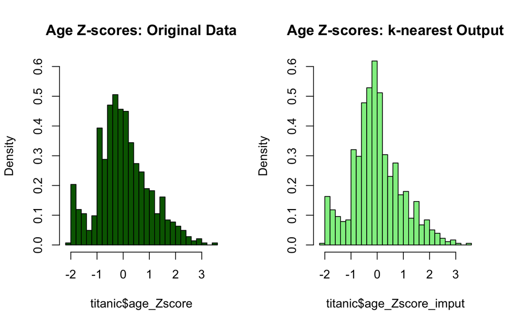

```r
# Plot age distributions
par(mfrow=c(1,2))
hist(titanic$age_Zscore, breaks=30, freq=F, main='Age Z-scores: Original Data', col='darkgreen', ylim=c(0,0.6))
hist(titanic$age_Zscore_imput, breaks=30, freq=F, main='Age Z-scores: k-nearest Output', col='lightgreen', ylim=c(0,0.6))
```

Looking good. Now let’s see how the distribution of the raw age data compares with our new imputed age data.

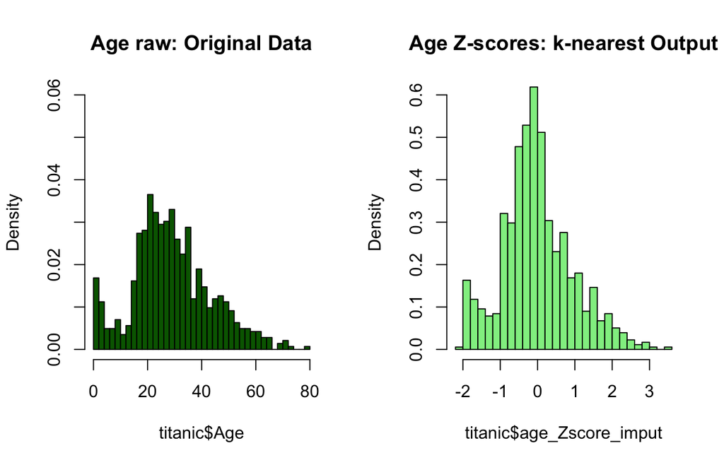

```r
# Plot age distributions
par(mfrow=c(1,2))
hist(titanic$Age, breaks=30, freq=F, main='Age raw: Original Data',
  col='darkgreen', ylim=c(0,0.06))
hist(titanic$age_Zscore_imput, breaks=30, freq=F, main='Age Z-scores: k-nearest Output',
  col='lightgreen', ylim=c(0,0.6))
```

Good - note that the Z-score imputed distribution on the right (which we will use as a feature) appears less positively skewed than the real age data.

Now let’s take a look at the distribution of the Fare variable - it might make sense to transform the data if it’s heavily skewed. Firstly, let’s plot the Fare data.

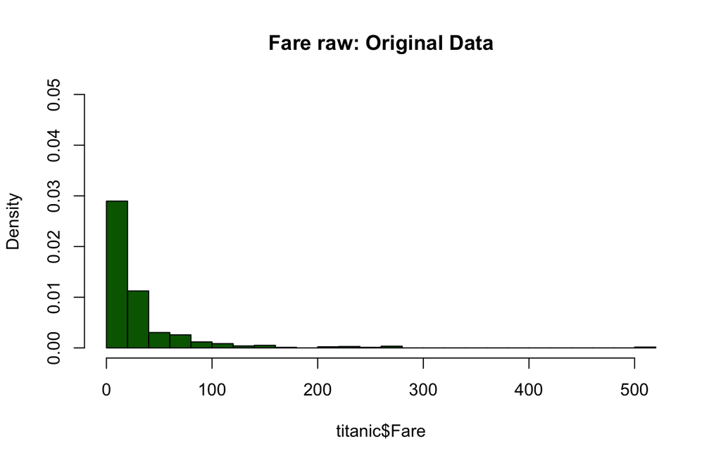

```r
hist(titanic$Fare, breaks = 30, freq=F, main='Fare raw: Original Data',
  col='darkgreen', ylim=c(0,0.05))
```

Yep! This data is very heavily positively skewed with a couple of very high-value outliers. It looks like there’s a number of people who paid a fare of zero. Is this missing data? Or did they really get a free ride? Let’s assume they got a free ride given that there was an NA value for Fare in the test set (i.e., we have both zero amounts and NAs so it’s safe to assume some passengers got a free ride). Let’s take a look at the data for those free tickets, I wonder if passengers were more likely to survive if they paid for a ticket?

```r
freeTicket <- titanic[titanic[, "Fare"] == 0,]
table(survived=freeTicket$Survived)
```

```
## survived
##  0  1
## 14  1
```

So 15 people got a free ride, they were all male, their aged ranged from 19 to 49, they all embarked at Southampton, and if we look at the survival rates we can see that only one of them survived. So it appears that a free ticket strongly predicts that a passenger does not survive. If the free tickets did not predict survival I’d suggest removing these passengers so that we can fit a log transform to the Fare data to remove the positive skew (we cannot apply a log transform to values of zero - this produces -Inf values). To demonstrate this, let’s add a constant of 0.0001 to all the Fare values and then apply the log transform…

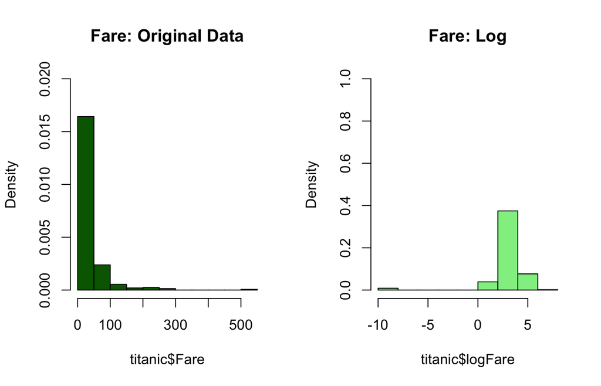

```r
# Add 0.0001 to all fares
titanic$Fare <- titanic$Fare+0.0001

# now get log fare
titanic$logFare <- log(titanic$Fare)

# plot raw fare agains log fare
par(mfrow=c(1,2))
hist(titanic$Fare, freq=F, main='Fare: Original Data',
  col='darkgreen', ylim=c(0,0.02))
hist(titanic$logFare, freq=F, main='Fare: Log',
  col='lightgreen', ylim=c(0,1))
```

Now we can see the problem - the log transformed fare data, like the original data, appears to have a somewhat binomial distribution due to the presence of those free tickets. Through eye-balling, the larger distribution in the log data appears to have a far more normal distribution than the raw fare data, which is heavily skewed. Let’s remove the log data and the added constant we applied to compute it and try transforming the raw fare data to Z-scores to see if that reduces the skew.

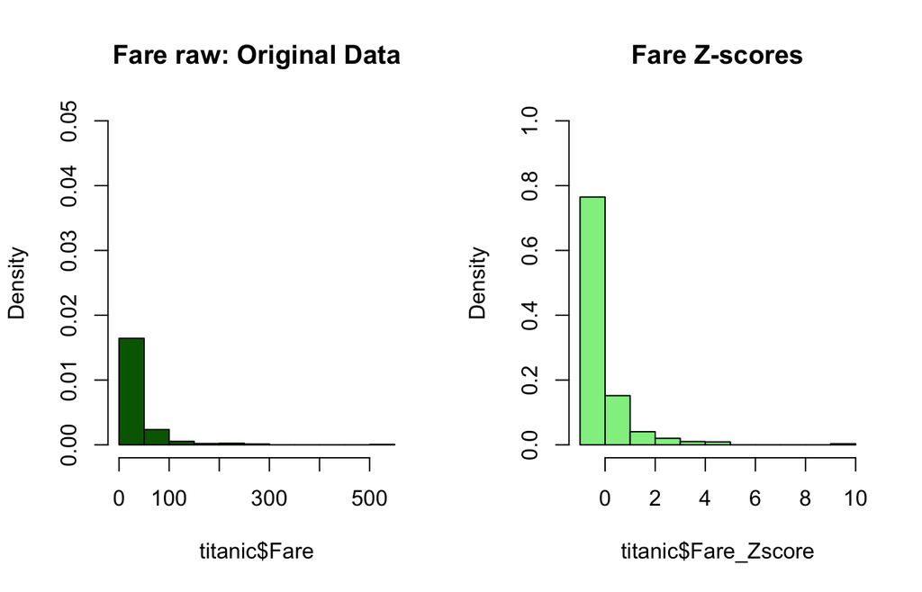

```r
titanic$logFare <- NULL # remove logFare column

titanic$Fare <- titanic$Fare-0.0001 # subtract the constant we applied earlier

titanic$Fare_Zscore <- (titanic$Fare-mean(titanic$Fare, na.rm=TRUE))/sd(titanic$Fare, na.rm=TRUE)

par(mfrow=c(1,2))
hist(titanic$Fare, freq=F, main='Fare raw: Original Data',
  col='darkgreen', ylim=c(0,0.05))
hist(titanic$Fare_Zscore, freq=F, main='Fare Z-scores',
  col='lightgreen', ylim=c(0,1))
```

```r
skewness(titanic$Fare, na.rm=TRUE) # old raw data
```

```
## [1] 4.78525
## attr(,"method")
## [1] "moment"
```

```r
skewness(titanic$Fare_Zscore, na.rm=TRUE) # Z-score data
```

```
## [1] 4.78525
## attr(,"method")
## [1] "moment"
```

```r
titanic$Fare_Zscore <- NULL # remove Fare Z-score column
```

The Z-scores are still very heavily skewed, indeed they have the same skew (4.785) value as the raw data. So despite our efforts it makes sense to stick with the raw data values.

# Feature Engineering

Now let’s now create a new variable ‘Title’ (e.g., Mr, Ms, Mrs) by extracting this info from the Name variable. This idea was based on Megan Risdale’s blog- https://www.kaggle.com/mrisdal/exploring-survival-on-the-titanic/notebook

```r
# First the titanic data (training data) -

titanic$Title <- gsub('(.*, )|(\\..*)', '', titanic$Name) # Grab title from passenger names

# Show title counts by sex
table(titanic$Sex, titanic$Title)
```

```
##
##          Capt Col Don  Dr Jonkheer Lady Major Master Miss Mlle Mme  Mr Mrs
##   female    0   0   0   1        0    1     0      0  181    2   1   0 124
##   male      1   2   1   6        1    0     2     40    0    0   0 517   0
##
##           Ms Rev Sir the Countess
##   female   1   0   0            1
##   male     0   6   1            0
```

```r
# Titles with very low cell counts to be combined to "rare" level
rare_title <- c('Dona', 'Lady', 'the Countess','Capt', 'Col', 'Don',
                'Dr', 'Major', 'Rev', 'Sir', 'Jonkheer')

# Also reassign mlle, ms, and mme accordingly
titanic$Title[titanic$Title == 'Mlle']        <- 'Miss'
titanic$Title[titanic$Title == 'Ms']          <- 'Miss'
titanic$Title[titanic$Title == 'Mme']         <- 'Mrs'
titanic$Title[titanic$Title %in% rare_title]  <- 'Rare Title'

# And now we do the same for the test data
test$Title <- gsub('(.*, )|(\\..*)', '', test$Name)

test$Title[test$Title == 'Mlle']        <- 'Miss'
test$Title[test$Title == 'Ms']          <- 'Miss'
test$Title[test$Title == 'Mme']         <- 'Mrs'
test$Title[test$Title %in% rare_title]  <- 'Rare Title'

# Show title counts by sex again
table(test$Sex, test$Title)
```

```
##
##          Master Miss  Mr Mrs Rare Title
##   female      0   79   0  72          1
##   male       21    0 240   0          5
```

Moving on, let’s now create a new variable **isChild** with two levels (0 = adult, 1 = child) by extracting info from the age variable.

```r
# We'll use the age Z score imputed data as the raw age data has missing values. Let's work out the Z-score threshold to be classified as a child (i.e., < 18 years)? -
Zscore_threshold <- (18-mean(titanic$Age, na.rm=TRUE))/sd(titanic$Age, na.rm=TRUE)

# Create the column child, and indicate whether child or adult
titanic$isChild[titanic$age_Zscore_imput < Zscore_threshold] <- 1
titanic$isChild[titanic$age_Zscore_imput >= Zscore_threshold] <- 0

# Let's double checked that worked as planned on the training set by selecting the value that's closest but smaller than the threshold (this passenger should be classified as being a child)

child_index <-which(titanic$age_Zscore_imput < Zscore_threshold) # get indices of all passengers with an age Z-score lower than our established Z-score threshold
children <- titanic[child_index,] # select these passengers
max_index <- which(children$Age==max(children$Age,na.rm=TRUE)) # from this subset of passengers, find the passenger with the highest value
children[max_index[1],] # finally check their age - it should be less than 18 if our procedure is working accurately
```

```
##    PassengerId Survived Pclass                            Name    Sex Age
## 69          69        1      3 Andersson, Miss. Erna Alexandra female  17
##    SibSp Parch  Ticket  Fare Cabin Embarked data_type age_Zscore
## 69     4     2 3101281 7.925              S  training -0.8722936
##    age_Zscore_imput Title isChild
## 69       -0.8722936  Miss       1
```

```r
adult_index <-which(titanic$age_Zscore_imput == Zscore_threshold) # get indices of all passengers with an age Z-score equal to our established Z-score threshold
adults <- titanic[adult_index,] # select these passengers
adults[1,] # check that these passengers are have an age of 18 and are therefore adults
```

```
##    PassengerId Survived Pclass                               Name    Sex
## 39          39        0      3 Vander Planke, Miss. Augusta Maria female
##    Age SibSp Parch Ticket Fare Cabin Embarked data_type age_Zscore
## 39  18     2     0 345764   18              S  training -0.8032945
##    age_Zscore_imput Title isChild
## 39       -0.8032945  Miss       0
```

```r
# And now do the same for the test set (we need a slightly different threshold as the age Z-scores here were calculated on the training set)
test$isChild[test$age_Zscore_imput <= -0.93] <- 1
test$isChild[test$age_Zscore_imput > -0.93] <- 0

# Let's double checked that worked as planned on the training set
which(test$Age == 17)
```

```
## [1]  61 126 188 213 270 316 404
```

```r
test[61,] # display data from the oldest possible child (Age should == 17)
```

```
##    PassengerId Pclass            Name  Sex Age SibSp Parch Ticket   Fare
## 61         952      3 Dika, Mr. Mirko male  17     0     0 349232 7.8958
##    Cabin Embarked data_type age_Zscore age_Zscore_imput Title isChild
## 61              S      test -0.8722936        -0.935928    Mr       1
```

```r
which(test$Age == 18)
```

```
##  [1]   9  63  67  88 116 168 183 198 239 311 341 353 396
```

```r
test[9,] # display data from the youngest possible adult (Age should == 18)
```

```
##   PassengerId Pclass                                      Name    Sex Age
## 9         900      3 Abrahim, Mrs. Joseph (Sophie Halaut Easu) female  18
##   SibSp Parch Ticket   Fare Cabin Embarked data_type age_Zscore
## 9     0     0   2657 7.2292              C      test -0.8032945
##   age_Zscore_imput Title isChild
## 9       -0.8654121   Mrs       0
```

```r
# Show counts
table(isChild=titanic$isChild,Survived= titanic$Survived)
```

```
##        Survived
## isChild   0   1
##       0 486 275
##       1  63  65
```

So we can see that passangers under the age of 18 had around a 50% survival rate, while for adults this drops to around 36%.

# Basic data exploration

First, let’s take a quick look at the relationship between age, gender and survival in the training set.

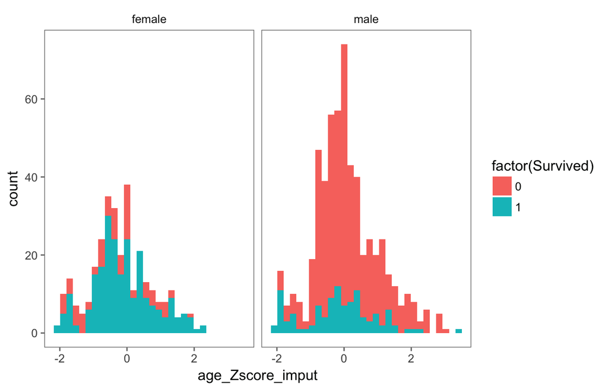

```r
ggplot(titanic, aes(age_Zscore_imput, fill = factor(Survived))) +
  geom_histogram() +
  facet_grid(.~Sex) +
  theme_few()
```

First off, we can see there are more males than females but the frequency distribution across genders appears roughly similar. More importantly, we can clearly see that the proprtion of male survivors to non-survivors is substantially less than for females.

Now let’s use featurePlot in the Caret package to get a further feel for the data and look for any particularly obvious trends in the training set amongst the other features.

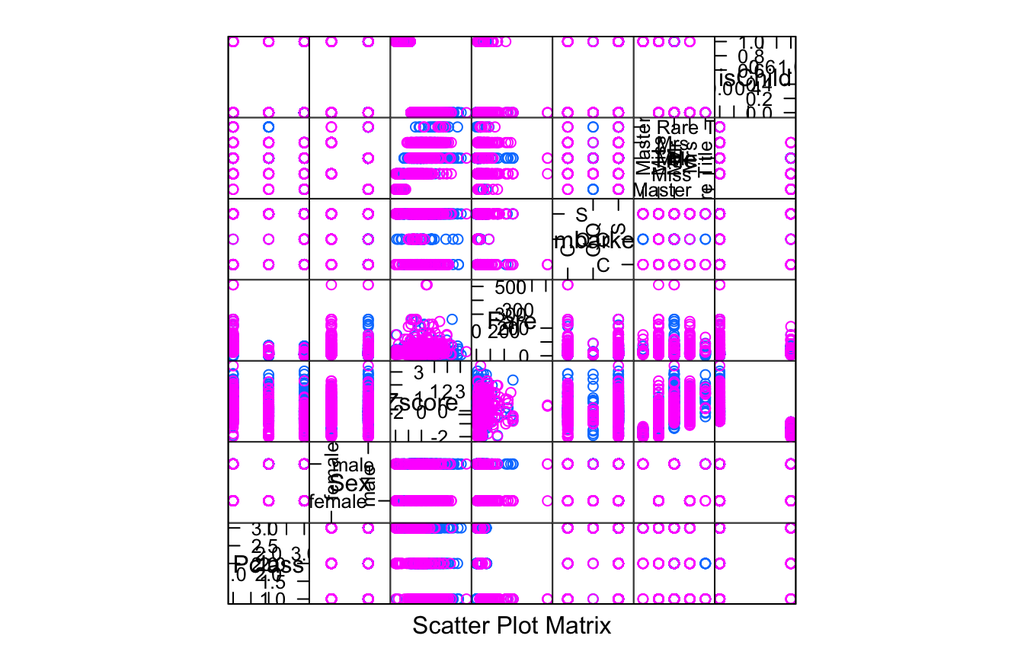

```r
# To use featurePlot we need to convert character variables to factors
titanic$Survived <- as.factor(titanic$Survived)
titanic$Sex <- as.factor(titanic$Sex)
titanic$Embarked <- as.factor(titanic$Embarked)
titanic$Title <- as.factor(titanic$Title)

featurePlot(x=titanic[,c("Pclass", "Sex", "age_Zscore_imput", "Fare", "Embarked", "Title", "isChild")],
            y=titanic$Survived, plot="pairs")
```

The feature titles from bottom left to top right: Class / Gender / Age (Z-score) / Fare / Embarked / Title / isChild

So there does not appear to be any one predictor that sticks out in terms of predicting survival, but we can see some basic trends (pink = survived, blue = did not survive): (1) There’s a greater age range for males vs. females and it looks like there’s a better chance of surviving for younger males compared with older males. (2) There were a few people aged around 40 years who paid a far higher fare (pretty much more than double) the rest of the passengers, and it looks like these ultra-high paying outliers survived. (3) Passengers paid more for 1st class (unsurprising) than 2nd and 3rd class, and these 1st class passengers tended to have a greater survival rate than non-1st class passengers.

Now let’s plot age against the fare paid separately for survivors and non-survivors and add a linerar regression to each.

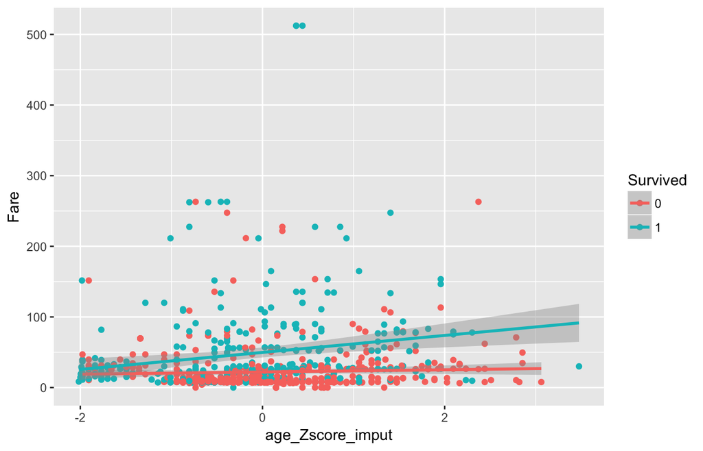

```r
#q-plots
qq <- qplot(age_Zscore_imput, Fare,colour=Survived,data = titanic) #add linear regression model
qq + geom_smooth(method = "lm", formula = y~x)
```

This plot shows an interesting relationship - firstly, survivors on average paid a higher fare than non-survivors but amongst survivors there’s a positive correlation between age and the fare paid. In other words, the older the passenger the greater the fare they needed to pay to survive. Sorry grandpa. There was no such relationship between these features for the non-survivors.

# Model Building

## GLM

Let’s start with basic glm model (generalized linear model).

```r
# First, we partition the training dataset into a training and a validation set
inTrain <-createDataPartition(y=titanic$Survived, p=0.7, list=FALSE)

training <-titanic[inTrain,] # subset the data to the intraining set
validation  <-titanic[-inTrain,] # subset the data for all samples that aren't in the training set (and are instead in the test set)
dim(training); dim(validation) # Check dimensions
```

```
## [1] 623  17
```

```
## [1] 266  17
```

```r
# Fit a basic glm
modFit_glm <- train(Survived ~ Pclass + Sex + age_Zscore_imput + SibSp + Parch +
                                            Fare + Embarked + Title +
                                            isChild, data=training, method="glm")

# suppressWarnings(modFit_glm)

print(modFit_glm)
```

```
## Generalized Linear Model
##
## 623 samples
##   9 predictor
##   2 classes: '0', '1'
##
## No pre-processing
## Resampling: Bootstrapped (25 reps)
## Summary of sample sizes: 623, 623, 623, 623, 623, 623, ...
## Resampling results:
##
##   Accuracy   Kappa
##   0.8184714  0.6082057
##
##
```

```r
modFit_glm$finalModel # look at final model (watch out for high values - may simply be due to overfitting)
```

```
##
## Call:  NULL
##
## Coefficients:
##       (Intercept)             Pclass            Sexmale
##         18.945921          -1.085151         -14.471492
##  age_Zscore_imput              SibSp              Parch
##         -0.564430          -0.486163          -0.521961
##              Fare          EmbarkedQ          EmbarkedS
##          0.003186          -0.242774          -0.441856
##         TitleMiss            TitleMr           TitleMrs
##        -14.797505          -3.223351         -13.918142
## `TitleRare Title`            isChild
##         -3.181559          -0.167256
##
## Degrees of Freedom: 622 Total (i.e. Null);  609 Residual
## Null Deviance:       828.6
## Residual Deviance: 515   AIC: 543
```

So the model produces an estimated accuracy of ~ 82% (Kappa = 0.61), let’s test this on the validation data.

```r
predictions <- predict(modFit_glm,newdata=validation)

#calculate confusion matrix to evaluate the predictions and pass the predictions from the model fit into the confusion matrix
confusionMatrix(predictions,validation$Survived)
```

```
## Confusion Matrix and Statistics
##
##           Reference
## Prediction   0   1
##          0 145  24
##          1  19  78
##
##                Accuracy : 0.8383
##                  95% CI : (0.7885, 0.8805)
##     No Information Rate : 0.6165
##     P-Value [Acc > NIR] : 2.231e-15
##
##                   Kappa : 0.6549
##  Mcnemar's Test P-Value : 0.5419
##
##             Sensitivity : 0.8841
##             Specificity : 0.7647
##          Pos Pred Value : 0.8580
##          Neg Pred Value : 0.8041
##              Prevalence : 0.6165
##          Detection Rate : 0.5451
##    Detection Prevalence : 0.6353
##       Balanced Accuracy : 0.8244
##
##        'Positive' Class : 0
##
```

This produced an accuracy of ~ 84% (Kappa = 0.65), not too dissimilar from our estimated accuracy. Now let’s separately apply it to the final test data and then save the predictions for the test data.

```r
# Apply to test set
prediction <- predict(modFit_glm,newdata=test)

# Save the solution to a dataframe with two columns: PassengerId and Survived (prediction)
solution_glm_1 <- data.frame(PassengerID = test$PassengerId, Survived = prediction)

# Write the solution to file
write.csv(solution_glm_1, file = 'glm_1_Solution.csv', row.names = F)
```

## K-means clustering

Let’s try some unsupervised learning in the form of k-means clustering to establish whether the algorithm can find patterns in the data corresponding to whether passengers survived. We’ll run this on numerical features (we can’t run this procedure on categorical features)

First let’s try with four numerical predictors - the age data (imputed Z-scores), the fare data, the number of siblings and the number of parents/children aboard.

```r
kMeans1 <- kmeans(training[,c(7,8,10,15)], 2, nstart = 20) # We specify 2 clusters corresponding to our binary variable "Survived"

training$clusters <- as.factor(kMeans1$cluster) # add column with outcome of clustering procedure for each entry

table(training$cluster, training$Survived) # compare the outcome to the real data
```

```
##
##       0   1
##   1   8  24
##   2 377 214
```

So we can see that two clusters were established as requested. Neither cluster reliably segregates survivors from non-survivors - ideally in both clusters we would have a high and a low number. Perhaps this was due to including two features that both contain a lot of zeros (the number of siblings and the number of parents/children aboard). Let’s focus instead on just the fare and age features to see if that works better.

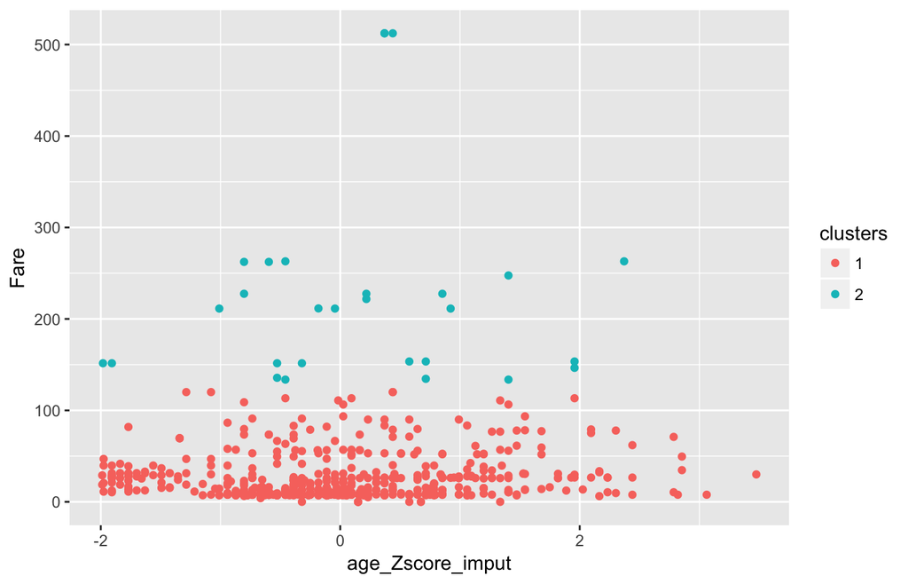

```r
kMeans1 <- kmeans(training[,c(10,15)], 2, nstart = 20) # this simply does the clustering

training$clusters <- as.factor(kMeans1$cluster) # add column with outcome of clustering procedure for each entry

qplot(age_Zscore_imput, Fare, colour = clusters, data = training) # plot the clustering
```

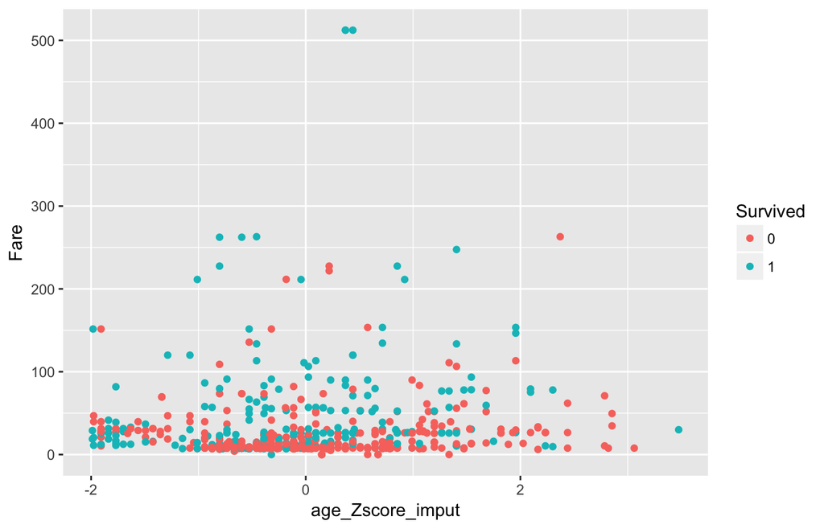

```r
qplot(age_Zscore_imput, Fare, colour = Survived, data = training) # plot the actual data for comparison
```

```r
table(training$cluster, training$Survived)
```

```
##
##       0   1
##   1 377 218
##   2   8  20
```

Comparing the plots we can see that the k-means classification produced the smallest cluster variation when it classifed anything with a fare above around 120 as one cluster and anything below as the second cluster (the first plot). Looking at the actual data (the second plot) shows that this doesn’t correspond well to the actual data. Let’s try an alternative approach: discriminant analysis.

## Linear discriminant analysis versus Quadratic discriminant analysis

LDA assumes features have a multivariate gaussian distribution with the same covariances for every class whereas QDA assumes different covariances. Let’s see if either of these related procedures are more/less successful at predicting survival. First off - linear discriminant analysis…

```r
# Linear discriminant analysis-
mod_lda <- train(Survived ~., data =training[,c(2,3,5,7,8, 10,12,15,17)], method = "lda") # I dropped Title from the feature input as this feature was causing colinearity problems

pred_lda = predict(mod_lda, validation)
```

And now for quadratic discriminant analysis…

```r
# Quadratic discriminant analysis-
mod_qda <- train(Survived ~., data =training[,c(2,3,5,7,8, 10,12,15,17)], method = "qda")

pred_qda = predict(mod_qda, validation);
```

Now let’s see if they made different predictions…

```r
table(pred_lda,pred_qda)
```

```
##         pred_qda
## pred_lda   0   1
##        0 157  15
##        1  11  83
```

So we can see the two procedures produced different predictions, let’s check if either was more/less accurate.

```r
# Show the output for lda first then qda
confusionMatrix(validation$Survived, predict(mod_lda, validation))
```

```
## Confusion Matrix and Statistics
##
##           Reference
## Prediction   0   1
##          0 141  23
##          1  31  71
##
##                Accuracy : 0.797
##                  95% CI : (0.7436, 0.8437)
##     No Information Rate : 0.6466
##     P-Value [Acc > NIR] : 6.246e-08
##
##                   Kappa : 0.5642
##  Mcnemar's Test P-Value : 0.3408
##
##             Sensitivity : 0.8198
##             Specificity : 0.7553
##          Pos Pred Value : 0.8598
##          Neg Pred Value : 0.6961
##              Prevalence : 0.6466
##          Detection Rate : 0.5301
##    Detection Prevalence : 0.6165
##       Balanced Accuracy : 0.7875
##
##        'Positive' Class : 0
##
```

```r
confusionMatrix(validation$Survived, predict(mod_qda, validation))
```

```
## Confusion Matrix and Statistics
##
##           Reference
## Prediction   0   1
##          0 140  24
##          1  28  74
##
##                Accuracy : 0.8045
##                  95% CI : (0.7517, 0.8504)
##     No Information Rate : 0.6316
##     P-Value [Acc > NIR] : 6.86e-10
##
##                   Kappa : 0.5835
##  Mcnemar's Test P-Value : 0.6774
##
##             Sensitivity : 0.8333
##             Specificity : 0.7551
##          Pos Pred Value : 0.8537
##          Neg Pred Value : 0.7255
##              Prevalence : 0.6316
##          Detection Rate : 0.5263
##    Detection Prevalence : 0.6165
##       Balanced Accuracy : 0.7942
##
##        'Positive' Class : 0
##
```

So, when tested on the validation data we find that Quadratic discriminant analysis (the second model) edges Linear discriminant analysis (the first model) with an accuracy of 80.5% versus 79.7%. Let’s apply the Quadratic discriminant analysis model to the testing set and save the predicted survival outcomes.

```r
# Predict using the test set
prediction <- predict(mod_qda, test)

# Save the solution to a dataframe with two columns: PassengerId and Survived (prediction)
solution_qda <- data.frame(PassengerID = test$PassengerId, Survived = prediction)

# Write the solution to file
write.csv(solution_qda, file = 'qda_mod_Solution.csv', row.names = F)
```

## Random forests

Finally, let’s apply the ensemble learning method ‘random forest’ algorithm to the training data and see if we can better tune the model to the dataset.

```r
mod_rf <- train(Survived ~ Pclass + Sex + age_Zscore_imput + SibSp + Parch +
                                            Fare + Embarked + Title +
                                            isChild, data = training, method = 'rf', prox = TRUE)
# View model fit
print(mod_rf)
```

```
## Random Forest
##
## 623 samples
##   9 predictor
##   2 classes: '0', '1'
##
## No pre-processing
## Resampling: Bootstrapped (25 reps)
## Summary of sample sizes: 623, 623, 623, 623, 623, 623, ...
## Resampling results across tuning parameters:
##
##   mtry  Accuracy   Kappa
##    2    0.8118776  0.5947835
##    7    0.8137590  0.6031445
##   13    0.7989274  0.5731242
##
## Accuracy was used to select the optimal model using  the largest value.
## The final value used for the model was mtry = 7.
```

So we get an estimated accuracy of ~81%. Now let’s see how that compares to the accuracy when predicting our pre-defined test (validation) set

```r
# Predicting new values in testing set:
pred <- predict(mod_rf, validation) # predict new values (classifications) based on model fit

validation$predRight <- pred == validation$Survived # add column for classification accuracy of each data point in testing set

predTable <-table(pred, validation$Survived) # display overall classification accuracy in a table

print(predTable)
```

```
##
## pred   0   1
##    0 148  25
##    1  16  77
```

So we get 225 (148+77) correct predictions out of 266 (an accuracy of 84.6%). The compares pretty well to our estimated accuracy. Now, can we improve the model further by tuning it? Here we want to establish the best mtry value. This is the number of variables randomly sampled as candidates at each split. Note that the original best mtry value was 7.

```r
# Re-run the procedure a number of times randomising mtry to establish best mtry value
control <- trainControl(method="repeatedcv", number=10, repeats=3, search="random")

metric <- "Accuracy"

mod_rf_multi <- train(Survived ~ Pclass + Sex + age_Zscore_imput + SibSp + Parch +
                                            Fare + Embarked + Title +
                                            isChild, data = training, method = 'rf', metric=metric, tuneLength=15, trControl=control)

# Show & plot estimated accuracy for the different iterations
print(mod_rf_multi)
```

```
## Random Forest
##
## 623 samples
##   9 predictor
##   2 classes: '0', '1'
##
## No pre-processing
## Resampling: Cross-Validated (10 fold, repeated 3 times)
## Summary of sample sizes: 561, 560, 561, 561, 560, 561, ...
## Resampling results across tuning parameters:
##
##   mtry  Accuracy   Kappa
##    2    0.8244249  0.6205231
##    3    0.8282748  0.6239300
##    4    0.8352388  0.6406054
##    6    0.8335656  0.6419564
##    7    0.8314236  0.6375751
##    8    0.8265667  0.6285107
##    9    0.8222827  0.6191633
##   10    0.8233491  0.6216102
##   11    0.8190569  0.6125437
##   13    0.8147640  0.6046718
##
## Accuracy was used to select the optimal model using  the largest value.
## The final value used for the model was mtry = 4.
```

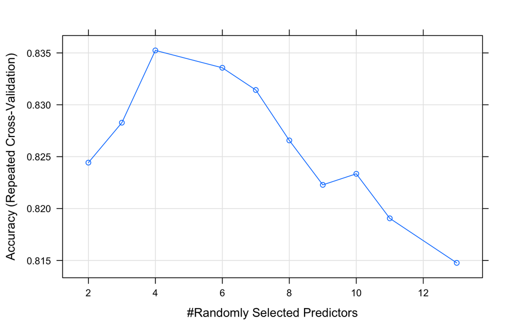

```r
plot(mod_rf_multi)
```

So the best value used for the model was mtry = 4 with an accuracy of ~ 83.5%. Let’s run the final tuned model on the validation data to see how it stands up.

```r
mtry <- 4

tunegrid <- expand.grid(.mtry=mtry)

mod_rf_multi_final <- train(Survived ~ Pclass + Sex + age_Zscore_imput + SibSp + Parch +
                                            Fare + Embarked + Title +
                                            isChild, data = validation, method = 'rf', metric=metric, tuneGrid=tunegrid, trControl=control)

# View model fit
print(mod_rf_multi_final)
```

```
## Random Forest
##
## 266 samples
##   9 predictor
##   2 classes: '0', '1'
##
## No pre-processing
## Resampling: Cross-Validated (10 fold, repeated 3 times)
## Summary of sample sizes: 240, 239, 240, 239, 240, 239, ...
## Resampling results:
##
##   Accuracy   Kappa
##   0.8433862  0.6591169
##
## Tuning parameter 'mtry' was held constant at a value of 4
##
```

```r
# Get ranked importance via regression coefficients (scaled to our data)
varImp(mod_rf_multi_final, scale = FALSE)
```

```
## rf variable importance
##
##                  Overall
## Fare             22.0356
## age_Zscore_imput 18.2669
## TitleMr          16.5463
## Sexmale          14.1206
## Pclass           12.0991
## SibSp             6.9293
## Parch             4.1457
## EmbarkedS         3.6498
## TitleMrs          3.3261
## TitleMiss         2.3026
## isChild           1.9372
## EmbarkedQ         1.6038
## TitleRare Title   0.7981
```

This analysis suggests the fare paid to be the principal predictor of survival, with the age coming a close second. Now let’s apply the model to the test data and save the predictions.

```r
# Predict using the test set
prediction <- predict(mod_rf_multi_final, test)

# Save the solution to a dataframe with two columns: PassengerId and Survived (prediction)
solution_rf <- data.frame(PassengerID = test$PassengerId, Survived = prediction)


# Write the solution to file
write.csv(solution_rf, file = 'rf_mod_Solution.csv', row.names = F)
```